# Flexible use of visual and acoustic cues during roost finding in Spix’s disc-winged bat

Statistical analysis

Author

Miriam Gioiosa, Marcelo Araya-Salas, Cristian Castillo-Salazar, Silvia Chaves-Ramirez, Maurizio Gioiosa, Nazareth Rojas, Mariela Sanchez, Dino Scaravelli, Gloriana Chaverri

Published

February 26, 2023

Source code and data also found at https://github.com/maRce10/Roost-finding-behavior-in-Thyroptera-tricolor

# Data analysis for the paper

Gioiosa, Miriam; Araya-Salas, Marcelo; Castillo Salazar, Cristian; Chaves-Ramírez, Silvia; Gioiosa, Maurizio; Rojas, Nazareth; Sanchez, Mariela; Scaravelli, Dino; Chaverri, Gloriana. 2023. *Flexible use of visual and acoustic cues during roost finding in Spix’s disc-winged bat*. Behavioral Ecology.

# Abstract

The ability of an animal to detect environmental cues is crucial for its survival and fitness. In bats, sound certainly plays a significant role in the search for food, spatial navigation and social communication. Yet, the efficiency of bat’s echolocation could be limited by atmospheric attenuation and background clutter. In this context, sound can be complemented by other sensory modalities, like smell or vision. Spix’s disc-winged bat uses acoustic cues from other group members to locate the roost (tubular unfurled leaves of plants in the order Zingiberales). Our research focused on how individuals find a roost that has not been yet occupied, considering the urge to find a suitable leaf approximately every day, during nighttime or in daylight. We observed the process of roost finding in T. tricolor in a flight cage, manipulating the audio/visual sensory input available for each trial. A broadband noise was broadcast in order to mask echolocation, while experiments conducted at night reduced significantly the amount of light. We measured the time needed to locate the roost under these different conditions. Results show that with limited visual and acoustic cues, search time increases significantly. In contrast bats seemed capable of using acoustic and visual cues in a similarly efficient manner, since roost search times were equally short when bats could use only sound, only vision, or both senses at the same time. Our results show that non-acoustic inputs can still be an important source of information for finding critical resources in bats.

# Load packages

First install/load packages:

```r
source("https://raw.githubusercontent.com/maRce10/sketchy/main/R/load_packages.R")

load_packages(c("readxl", "brms", "viridis", "ggplot2", "pbapply",
    "cowplot", "kableExtra", "warbleR", github = "maRce10/brmsish"))
```

# Read and prepare data

The data file can be downloaded at the paper’s dryad repository or at the github repository ([link](https://raw.githubusercontent.com/maRce10/Roost-finding-behavior-in-Thyroptera-tricolor/main/data/raw/time_entering_roost_thyroptera.csv))

```r
total_dat <- read.csv("Supp_Mat_1-time_entering_roost_thyroptera.csv")

total_dat$sensory_input <- factor(total_dat$sensory_input, levels = c("Sound & vision",
    "Noise control", "Sound", "Vision", "Lessen input"))
```

Sensory input treatments:

- Sound & vision: diurnal experiments with no noise playback
- Noise control: diurnal experiments with control (no echolocation-masking) playback
- Sound: nocturnal experiments with no playback
- Vision: diurnal experiments with echolocation-masking playback
- Lessen input: nocturnal experiments with echolocation-masking playback

# 1 Sample sizes

First, exclude individuals with 1 experiment:

```r
tab <- table(total_dat$individual[!duplicated(paste(total_dat$sensory_input,
    total_dat$individual))])

dat <- total_dat[!total_dat$individual %in% names(tab)[tab == 1],
    ]
```

Experiments per date:

```r
# Dates
table(dat$date)
```

```
2019-11-06 2019-11-09 2019-11-10 2019-11-11 2019-11-12 2019-11-13 2019-11-14
         4          3          4          3          4          7          4
2019-11-16 2019-11-17 2019-11-19 2019-11-25 2019-11-26 2019-11-27 2019-11-28
         3          7          6          3          6          9          4
2019-11-29 2019-12-01 2019-12-07 2020-01-24 2020-01-28 2020-01-29
         6          3          2          4          4         10
```

Test per individual:

```r
table(dat$individual)
```

```
982.126051278486 982.126051278498 982.126051278508 982.126051278509
               3                7                2                4
982.126051278515 982.126051278518 982.126051278520 982.126051278530
               3                3                4                3
982.126051278531 982.126051278554 982.126051278558 982.126051278559
               6                3                3                3
982.126051278588 982.126057845184 982.126057845188 982.126057845230
               3                4                3                3
982.126058484283 982.126058484309 982.126058484311 982.126058484344
               3                3                3                6
982.126058484345 982.126058484348  982126052945834  982126052945878
               3                3                2                2
 982126052945887  982126052945892  982126052945893  982126052945904
               2                2                2                2
 982126052945905  982126058484333  982126058484340
               2                2                2
```

Number of individuals by number of tests:

```r
aggregate(individual ~ sensory_input, dat, function(x) length(unique(x)))
```

| sensory_input | individual |
| --- | --- |
| Sound & vision | 22 |
| Noise control | 21 |
| Sound | 9 |
| Vision | 22 |
| Lessen input | 9 |

Experiments per individual:

```r
table(dat$individual[!duplicated(paste(dat$sensory_input, dat$individual))])
```

```
982.126051278486 982.126051278498 982.126051278508 982.126051278509
               3                3                2                3
982.126051278515 982.126051278518 982.126051278520 982.126051278530
               3                3                3                3
982.126051278531 982.126051278554 982.126051278558 982.126051278559
               3                3                3                3
982.126051278588 982.126057845184 982.126057845188 982.126057845230
               3                3                3                3
982.126058484283 982.126058484309 982.126058484311 982.126058484344
               3                3                3                3
982.126058484345 982.126058484348  982126052945834  982126052945878
               3                3                2                2
 982126052945887  982126052945892  982126052945893  982126052945904
               2                2                2                2
 982126052945905  982126058484333  982126058484340
               2                2                2
```

Number of individuals by number of experiments:

```r
table(table(dat$individual[!duplicated(paste(dat$sensory_input, dat$individual))]))
```

```
 2  3
10 21
```

Tests per treatment:

```r
table(dat$sensory_input, dat$time_of_the_day)
```

```
                 day night
  Sound & vision  24     0
  Noise control   30     0
  Sound            0     9
  Vision          24     0
  Lessen input     0     9
```

Experiments per treatment:

```r
table(dat$sensory_input[!duplicated(paste(dat$sensory_input, dat$individual))],
    dat$time_of_the_day[!duplicated(paste(dat$sensory_input, dat$individual))])
```

```
                 day night
  Sound & vision  22     0
  Noise control   21     0
  Sound            0     9
  Vision          22     0
  Lessen input     0     9
```

# 2 Effect of sensory input on the time to find the roost

Bayesian generalized linear models on time (in s) to enter the roost, with individual as a random effect and sensory input treatment as predictors. An intercept-only (null) model was also included in the analysis:

1. Sensory input as a categorical variable:
   $$Time\ to\ enter\ roost \sim + categorical\ input + (1 | individual)$$
2. Null model with no predictor:
   $$Time\ to\ enter\ roost \sim 1 + (1 | individual)$$

A loop is used to run these models, 4 chains per model, 5000 iterations each. Models were run on the complete data set and on a subset including only trials in which individuals entered the roost.

## 2.1 Models using all the data

Raw data plot

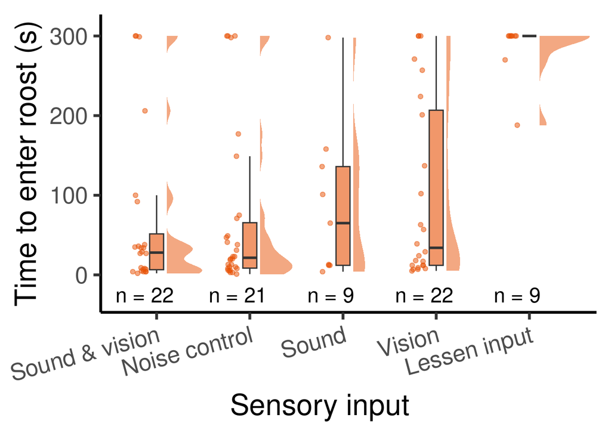

```r
cols <- viridis(10)

agg_dat <- aggregate(time_to_enter ~ sensory_input, dat, mean)
agg_dat$n <- sapply(1:nrow(agg_dat), function(x) length(unique(dat$individual[dat$sensory_input == agg_dat$sensory_input[x]])))
agg_dat$n.labels <- paste("n =", agg_dat$n)
agg_dat$sensory_input <- factor(agg_dat$sensory_input)

# raincoud plot:
fill_color <- adjustcolor("#e85307", 0.6)

ggplot(dat, aes(y = time_to_enter, x = sensory_input)) +
  # add half-violin from {ggdist} package
  ggdist::stat_halfeye(
    fill = fill_color,
    alpha = 0.5,
    # custom bandwidth
    adjust = .5,
    # adjust height
    width = .6,
    .width = 0,
    # move geom to the cright
    justification = -.2,
    point_colour = NA
  ) +
  geom_boxplot(fill = fill_color,
    width = .15,
    # remove outliers
    outlier.shape = NA # `outlier.shape = NA` works as well
  ) +
  # add justified jitter from the {gghalves} package
  gghalves::geom_half_point(
    color = fill_color,
    # draw jitter on the left
    side = "l",
    # control range of jitter
    range_scale = .4,
    # add some transparency
    alpha = .5,
    transformation = ggplot2::position_jitter(height = 0)
  ) +
   ylim(c(-30, 310)) +
  geom_text(data = agg_dat, aes(y = rep(-25, 5), x = sensory_input, label = n.labels), nudge_x = -0.13, size = 6) +
   scale_x_discrete(labels=c("Control" = "Noise control", "Sound vision" = "Sound & vision", "Vision" = "Vision", "Lessen input" = "Lessen input")) +
  labs(x = "Sensory input       ", y = "Time to enter roost (s)") + theme(axis.text.x = element_text(angle = 15, hjust = 1))
```

```r
# ggsave(filename = "./output/time_to_enter_by_treatment.tiff", dpi = 300, width = 3000, height = 1500, units = "px")
```

```r
model_formulas <- c("time_to_enter ~ sensory_input + (1 | individual)",
    "time_to_enter ~ 1 + (1 | individual)")

iter <- 5000
chains <- 4

priors <- c(set_prior("student_t(10,0,1)", class = "sigma"), set_prior("student_t(10,0,1)",
    class = "sd"))


# Run loops with models
brms_models <- lapply(model_formulas, function(x) {

    mod <- brm(formula = x, iter = iter, thin = 1, data = dat, family = lognormal(),
        silent = 2, chains = chains, cores = chains, prior = priors)

    mod <- add_criterion(mod, c("loo"), save_pars = save_pars(all = TRUE))

    return(mod)
})

names(brms_models) <- model_formulas

saveRDS(brms_models, "./data/processed/regresion_models_brms.RDS")
```

```r
brms_models <- readRDS("./data/processed/regresion_models_brms.RDS")

comp_mods <- loo_compare(brms_models[[1]], brms_models[[2]], model_names = names(brms_models))

df1 <- kbl(comp_mods, row.names = TRUE, escape = FALSE, format = "html",
    digits = 3)

cat("Compare models:")
```

Compare models:

```r
kable_styling(df1, bootstrap_options = c("striped", "hover", "condensed",
    "responsive"), full_width = FALSE, font_size = 12)
```

|  | elpd_diff | se_diff | elpd_loo | se_elpd_loo | p_loo | se_p_loo | looic | se_looic |
| --- | --- | --- | --- | --- | --- | --- | --- | --- |
| time_to_enter ~ sensory_input + (1 \| individual) | 0.000 | 0.000 | -510.740 | 16.182 | 20.972 | 1.890 | 1021.481 | 32.364 |
| time_to_enter ~ 1 + (1 \| individual) | -7.225 | 3.742 | -517.965 | 16.101 | 19.136 | 1.764 | 1035.930 | 32.202 |

```r
cat("Best model:\n")
```

Best model:

```r
cat(paste("-  ", rownames(comp_mods)[1], "\n"))
```

- time_to_enter ~ sensory_input + (1 | individual)

```r
# best model
if (!grepl("1 +", rownames(comp_mods)[1], fixed = TRUE)) extended_summary(fit = brms_models[[ rownames(comp_mods)[1]]],
    gsub.pattern = "sensory_input", gsub.replacement = "", fill = "#e85307",
    trace.palette = terrain.colors, print.name = FALSE)
```

|  | priors | formula | iterations | chains | thinning | warmup | diverg_transitions | rhats > 1.05 | min_bulk_ESS | min_tail_ESS | seed |
| --- | --- | --- | --- | --- | --- | --- | --- | --- | --- | --- | --- |
| 1 | Intercept-student_t(3, 3.5, 2.5) sd-student_t(10,0,1) sigma-student_t(10,0,1) | time_to_enter ~ sensory_input + (1 \| individual) | 5000 | 4 | 1 | 2500 | 0 | 0 | 7632.569 | 7283.589 | 652773362 |

|  | Estimate | l-95% CI | u-95% CI | Rhat | Bulk_ESS | Tail_ESS |
| --- | --- | --- | --- | --- | --- | --- |
| b_Intercept | 3.228 | 2.643 | 3.827 | 1 | 7632.569 | 7360.967 |
| b_Noisecontrol | 0.208 | -0.424 | 0.854 | 1 | 13237.365 | 7884.717 |
| b_Sound | 0.476 | -0.647 | 1.636 | 1 | 8482.597 | 7968.398 |
| b_Vision | 0.604 | -0.075 | 1.269 | 1 | 13132.351 | 7283.589 |
| b_Lesseninput | 2.407 | 1.284 | 3.534 | 1.001 | 8279.037 | 7899.409 |

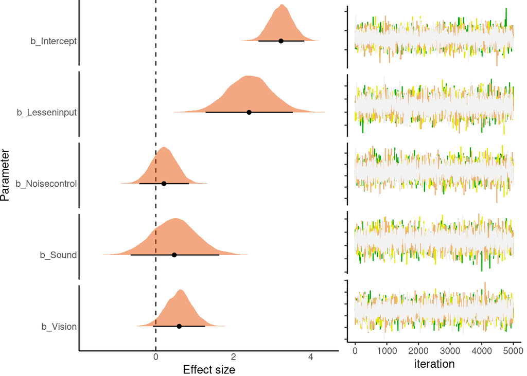

Compare all contrasts

|  | Hypothesis | Estimate | Est.Error | l-95% CI | u-95% CI |
| --- | --- | --- | --- | --- | --- |
| 1 | Lessen input VS Vision | 1.803 | 0.571 | 0.669 | 2.918 |
| 2 | Lessen input VS Sound | 1.931 | 0.570 | 0.811 | 3.062 |
| 3 | Lessen input VS Sound & vision | 2.407 | 0.572 | 1.284 | 3.534 |
| 4 | Lessen input VS Noise control | 2.198 | 0.561 | 1.079 | 3.262 |
| 5 | Vision VS Sound | 0.128 | 0.577 | -1.022 | 1.257 |
| 6 | Vision VS Sound & vision | 0.604 | 0.344 | -0.075 | 1.269 |
| 7 | Vision VS Noise control | 0.395 | 0.331 | -0.245 | 1.044 |
| 8 | Sound VS Sound & vision | 0.476 | 0.574 | -0.647 | 1.636 |
| 9 | Sound VS Noise control | 0.267 | 0.568 | -0.859 | 1.405 |
| 10 | Sound & vision VS Noise control | 0.208 | 0.325 | -0.424 | 0.854 |

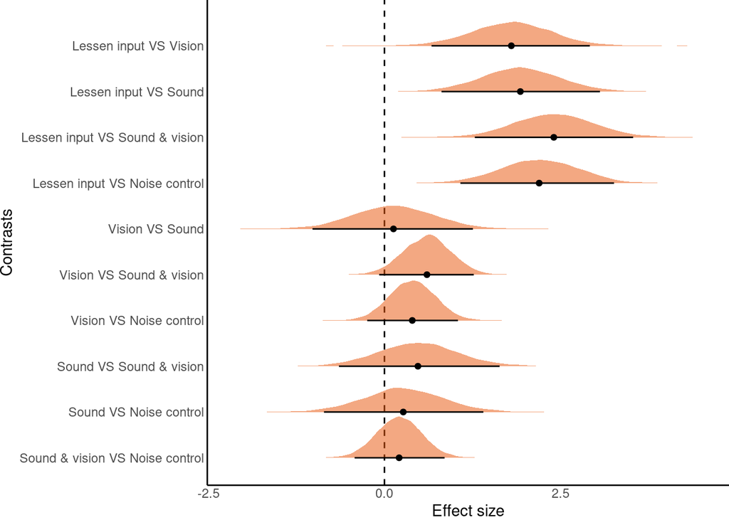

```r
# contrasts
contrasts(fit = brms_models[[ rownames(comp_mods)[1]]], predictor = "sensory_input",
    n.posterior = 2000, level.sep = " VS ", fill = "#e85307", gsub.pattern = c("Lesseninput",
        "Soundvision", "Noisecontrol"), gsub.replacement = c("Lessen input",
        "Sound & vision", "Noise control"), html.table = TRUE, plot = TRUE,
    sort.levels = c("Lessen input", "Vision", "Sound", "Sound & vision",
        "Noise control"))
```

```r
ggsave(filename = "./output/contrasts_between_treatments.tiff", dpi = 300,
    width = 2000, height = 1000, units = "px")
```

### 2.1.1 Takeaways

- “lessen input” was the only sensory input treatment in which a increase in time was detected: it show a longer time to enter the roost than all other treatments

## 2.2 Models on the data excluding bats that did not enter the roost

Raw data plot

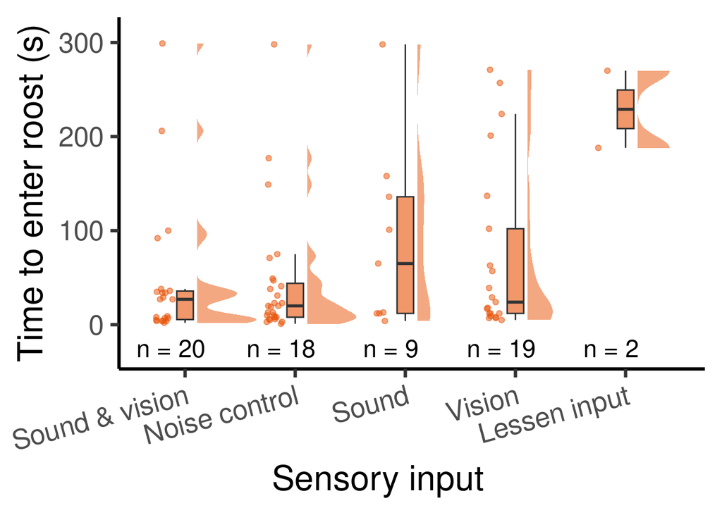

```r
agg_dat <- aggregate(time_to_enter ~ sensory_input, dat[dat$time_to_enter < 300, ], mean)
agg_dat$n <- sapply(1:nrow(agg_dat), function(x) length(unique(dat$individual[dat$sensory_input == agg_dat$sensory_input[x] & dat$time_to_enter < 300])))
agg_dat$labels <- c("a", "a", "a", "a", "b")
agg_dat$n.labels <- paste("n =", agg_dat$n)
agg_dat$sensory_input <- factor(agg_dat$sensory_input)

# raincoud plot:

ggplot(dat[dat$time_to_enter < 300, ], aes(y = time_to_enter, x = sensory_input)) +
  # add half-violin from {ggdist} package
  ggdist::stat_halfeye(
    fill = fill_color,
    alpha = 0.5,
    # custom bandwidth
    adjust = .5,
    # adjust height
    width = .6,
    .width = 0,
    # move geom to the cright
    justification = -.2,
    point_colour = NA
  ) +
  geom_boxplot(fill = fill_color,
    width = .15,
    # remove outliers
    outlier.shape = NA # `outlier.shape = NA` works as well
  ) +
  # add justified jitter from the {gghalves} package
  gghalves::geom_half_point(
    color = fill_color,
    # draw jitter on the left
    side = "l",
    # control range of jitter
    range_scale = .4,
    # add some transparency
    alpha = .5,
    transformation = ggplot2::position_jitter(height = 0)
  ) +
   ylim(c(-30, 310)) +
  # geom_text(data = agg_dat, aes(y = rep(340, 5), x = sensory_input, label = labels), size = 7) +
  geom_text(data = agg_dat, aes(y = rep(-25, 5), x = sensory_input, label = n.labels), nudge_x = -0.13, size = 6) +
   scale_x_discrete(labels=c("Control" = "Noise control", "Sound vision" = "Sound & vision", "Vision" = "Vision", "Lessen input" = "Lessen input")) +
  labs(x = "Sensory input       ", y = "Time to enter roost (s)") + theme(axis.text.x = element_text(angle = 15, hjust = 1))
```

```r
model_formulas <- c("time_to_enter ~ sensory_input + (1 | individual)",
    "time_to_enter ~ 1 + (1 | individual)")

iter <- 5000
chains <- 4
priors <- c(set_prior("student_t(10,0,1)", class = "sigma"), set_prior("student_t(10,0,1)",
    class = "sd"))


# Run loops with models
brms_models <- lapply(model_formulas, function(x) {

    mod <- brm(formula = x, iter = iter, thin = 1, data = dat[dat$time_to_enter <
        300, ], family = lognormal(), silent = 2, chains = chains,
        cores = chains, prior = priors, control = list(adapt_delta = 0.99,
            max_treedepth = 15))

    mod <- add_criterion(mod, c("loo"), save_pars = save_pars(all = TRUE))

    return(mod)
})

names(brms_models) <- model_formulas

saveRDS(brms_models, "./data/processed/regression_models_brms_subset.RDS")
```

```r
brms_models <- readRDS("./data/processed/regression_models_brms_subset.RDS")

comp_mods <- loo_compare(brms_models[[1]], brms_models[[2]], model_names = names(brms_models))


df1 <- kbl(comp_mods, row.names = TRUE, escape = FALSE, format = "html",
    digits = 3)

cat("Compare models:")
```

Compare models:

```r
kable_styling(df1, bootstrap_options = c("striped", "hover", "condensed",
    "responsive"), full_width = FALSE, font_size = 12)
```

|  | elpd_diff | se_diff | elpd_loo | se_elpd_loo | p_loo | se_p_loo | looic | se_looic |
| --- | --- | --- | --- | --- | --- | --- | --- | --- |
| time_to_enter ~ sensory_input + (1 \| individual) | 0.000 | 0.000 | -398.054 | 14.044 | 18.956 | 1.898 | 796.107 | 28.087 |
| time_to_enter ~ 1 + (1 \| individual) | -2.318 | 2.771 | -400.372 | 14.170 | 15.192 | 1.660 | 800.744 | 28.340 |

```r
cat("Best model:\n")
```

Best model:

```r
cat(paste("-  ", rownames(comp_mods)[1], "\n"))
```

- time_to_enter ~ sensory_input + (1 | individual)

```r
# best model
if (!grepl("1 +", rownames(comp_mods)[1], fixed = TRUE)) extended_summary(fit = brms_models[[ rownames(comp_mods)[1]]],
    gsub.pattern = "sensory_input", gsub.replacement = "", fill = "#e85307",
    trace.palette = terrain.colors, print.name = FALSE)
```

|  | priors | formula | iterations | chains | thinning | warmup | diverg_transitions | rhats > 1.05 | min_bulk_ESS | min_tail_ESS | seed |
| --- | --- | --- | --- | --- | --- | --- | --- | --- | --- | --- | --- |
| 1 | Intercept-student_t(3, 3.1, 2.5) sd-student_t(10,0,1) sigma-student_t(10,0,1) | time_to_enter ~ sensory_input + (1 \| individual) | 5000 | 4 | 1 | 2500 | 0 | 0 | 5171.14 | 6488.326 | 1582467647 |

|  | Estimate | l-95% CI | u-95% CI | Rhat | Bulk_ESS | Tail_ESS |
| --- | --- | --- | --- | --- | --- | --- |
| b_Intercept | 3.018 | 2.417 | 3.634 | 1 | 5171.140 | 6488.326 |
| b_Noisecontrol | 0.124 | -0.554 | 0.803 | 1 | 8844.558 | 7129.572 |
| b_Sound | 0.693 | -0.388 | 1.814 | 1 | 6254.619 | 6711.689 |
| b_Vision | 0.518 | -0.186 | 1.225 | 1 | 9433.443 | 7726.126 |
| b_Lesseninput | 2.948 | 0.985 | 4.924 | 1 | 7428.895 | 7424.103 |

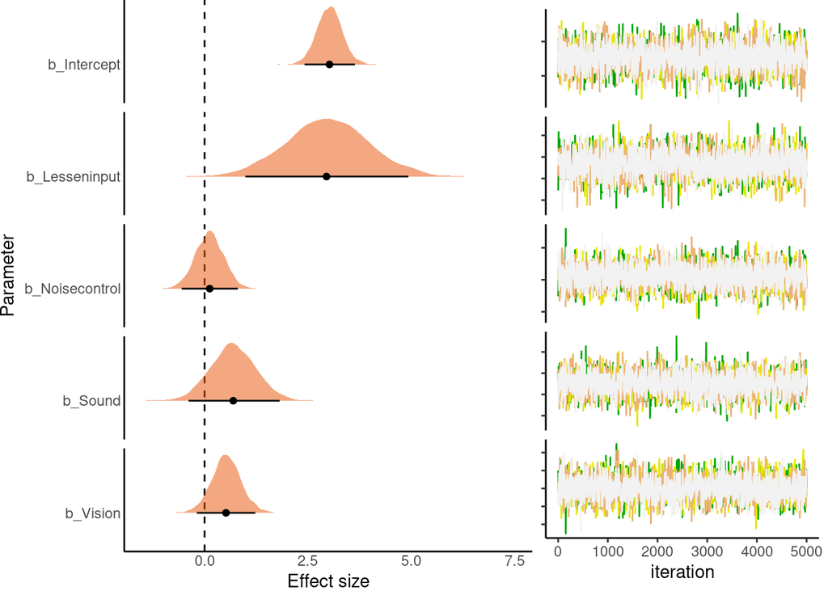

Compare all contrasts

|  | Hypothesis | Estimate | Est.Error | l-95% CI | u-95% CI |
| --- | --- | --- | --- | --- | --- |
| 1 | Lessen input VS Vision | 2.429 | 1.008 | 0.472 | 4.434 |
| 2 | Lessen input VS Sound | 2.255 | 1.008 | 0.256 | 4.221 |
| 3 | Lessen input VS Sound & vision | 2.948 | 1.000 | 0.985 | 4.924 |
| 4 | Lessen input VS Noise control | 2.824 | 0.992 | 0.906 | 4.778 |
| 5 | Vision VS Sound | -0.175 | 0.555 | -1.277 | 0.922 |
| 6 | Vision VS Sound & vision | 0.518 | 0.356 | -0.186 | 1.225 |
| 7 | Vision VS Noise control | 0.394 | 0.345 | -0.285 | 1.081 |
| 8 | Sound VS Sound & vision | 0.693 | 0.560 | -0.388 | 1.814 |
| 9 | Sound VS Noise control | 0.569 | 0.552 | -0.516 | 1.656 |
| 10 | Sound & vision VS Noise control | 0.124 | 0.343 | -0.554 | 0.803 |

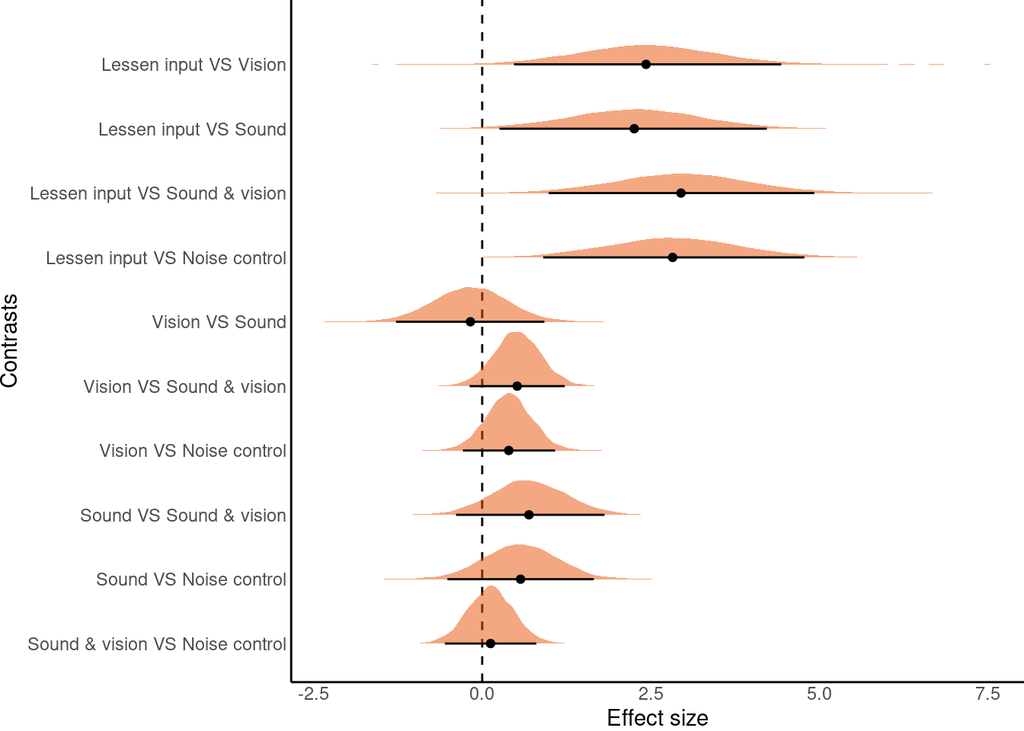

```r
# contrasts
contrasts(fit = brms_models[[ rownames(comp_mods)[1]]], predictor = "sensory_input",
    n.posterior = 2000, level.sep = " VS ", fill = "#e85307", gsub.pattern = c("Lesseninput",
        "Soundvision", "Noisecontrol"), gsub.replacement = c("Lessen input",
        "Sound & vision", "Noise control"), html.table = TRUE, plot = TRUE,
    sort.levels = c("Lessen input", "Vision", "Sound", "Sound & vision",
        "Noise control"))
```

### 2.2.1 Takeaways

- Results remain qualitatively similar after excluding individuals that did not enter the roost

# 3 Treatment diagram

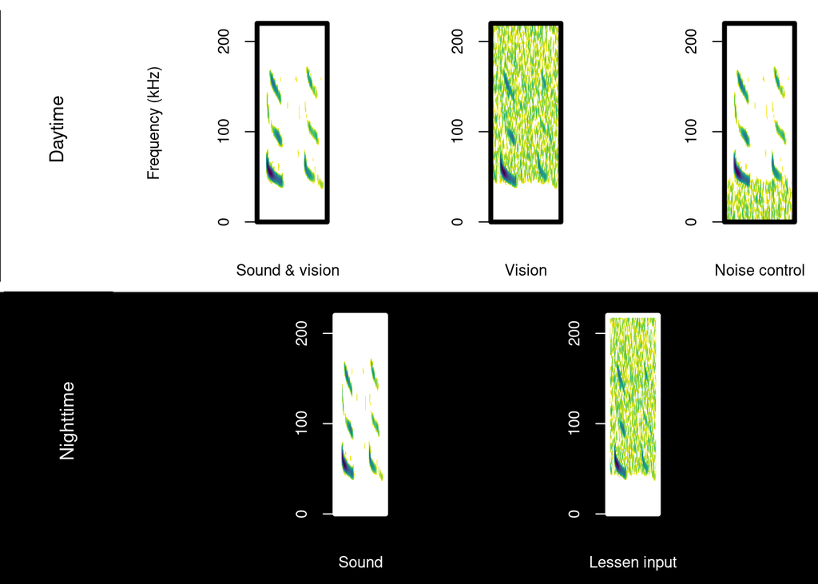

```r
reverse.viridis <- function(...) viridis(..., direction = -1)

wv <- read_wave("https://github.com/maRce10/Roost-finding-behavior-in-Thyroptera-tricolor/raw/main/data/raw/thyroptera_echolocation_clip.wav")


wv <- ffilter(wv, from = 40000, to = 170000, bandpass = TRUE, output = "Wave")

wv1 <- cutw(wv, from = 0.005, to = 0.009, output = "Wave")
wv2 <- cutw(wv, from = 0.036, to = duration(wv) - 0.004, output = "Wave")

subwv <- pastew(wv1, wv2, output = "Wave")

ns <- seewave::noisew(f = subwv@samp.rate, output = "Wave", d = duration(subwv))


mask <- ffilter(ns, from = 0, to = 45000, bandpass = FALSE, output = "Wave")

no_mask <- ffilter(ns, from = 0, to = 45000, bandpass = TRUE, output = "Wave")

subwv@left <- subwv@left[1:length(mask)]

ovlp <- 99
cex <- 0.8  # try cex 2 for saving plot
res <- 200
bl <- 4
hgh <- wdh <- 480 * 4

lf <- c(0, 2/14, 6/14, 10/14, 0, 1/6, 1/2, 5/6)
rgh <- c(2/14, 6/14, 10/14, 1, 1/6, 1/2, 5/6, 1)
btm <- c(1/2, 1/2, 1/2, 1/2, 0, 0, 0, 0)
tp <- c(1, 1, 1, 1, 1/2, 1/2, 1/2, 1/2)
m <- cbind(lf, rgh, btm, tp)

# graphics.off()
invisible(close.screen(all.screens = TRUE))

# tiff(filename = './output/diagram_experimental_design.tiff',
# res = 300, width = 3500, height = 2000)

sc <- split.screen(figs = m)

# sound and vision
screen(2)

par(mar = c(3, 6, 1, 1))
warbleR:::spectro_wrblr_int2(subwv, grid = FALSE, collev.min = -35,
    wl = 120, palette = reverse.viridis, ovlp = ovlp, zp = 1000, tlim = c(0.001,
        0.0085), axisX = FALSE, tlab = NULL, axisY = FALSE, flab = NULL,
    flim = c(0, 220))

box(lwd = bl)

axis(side = 2, cex.axis = cex, labels = c(0, 100, 200), at = c(0,
    100, 200))

mtext(side = 2, text = "Frequency (kHz)", line = 4, cex = cex)

mtext(side = 1, text = "Sound & vision  ", line = 1.5, cex = cex)


# vision
screen(3)
par(mar = c(3, 6, 1, 1))
warbleR:::spectro_wrblr_int2(subwv + mask * 1000, grid = FALSE, collev.min = -35,
    wl = 120, palette = reverse.viridis, ovlp = ovlp, zp = 1000, tlim = c(0.001,
        0.0085), axisX = FALSE, tlab = NULL, axisY = FALSE, flab = NULL,
    flim = c(0, 220))

box(lwd = bl)

axis(side = 2, cex.axis = cex, labels = c(0, 100, 200), at = c(0,
    100, 200))

mtext(side = 1, text = "Vision", line = 1.5, cex = cex)

# Noise control

screen(4)

par(mar = c(3, 6, 1, 1), new = TRUE)
warbleR:::spectro_wrblr_int2(subwv + no_mask * 1000, grid = FALSE,
    collev.min = -35, wl = 120, palette = reverse.viridis, ovlp = ovlp,
    zp = 1000, tlim = c(0.001, 0.0085), axisX = FALSE, tlab = NULL,
    axisY = FALSE, flab = NULL, flim = c(0, 220))

box(lwd = bl)

axis(side = 2, cex.axis = cex, labels = c(0, 100, 200), at = c(0,
    100, 200))

mtext(side = 1, text = "Noise control", line = 1.5, cex = cex)


# sound
par(bg = "black", new = TRUE)
screen(6)

par(mar = c(3, 8.5, 1, 1))
warbleR:::spectro_wrblr_int2(subwv, grid = FALSE, collev.min = -35,
    wl = 120, palette = reverse.viridis, ovlp = ovlp, zp = 1000, tlim = c(0.001,
        0.0085), axisX = FALSE, tlab = NULL, axisY = FALSE, flab = NULL,
    flim = c(0, 220))

box(lwd = bl, col = "white")

axis(side = 2, cex.axis = cex, labels = c(0, 100, 200), at = c(0,
    100, 200), col.ticks = "white", col = "white", col.axis = "white")

mtext(side = 1, text = "Sound", line = 1.5, cex = cex, col = "white")


# lessen input
par(bg = "black", new = TRUE)
screen(7)

par(mar = c(3, 8.5, 1, 1))

# par(mar = c(1, 9, 1, 1), bg = 'black', new = TRUE)
warbleR:::spectro_wrblr_int2(subwv + mask * 1000, grid = FALSE, collev.min = -35,
    wl = 120, palette = reverse.viridis, ovlp = ovlp, zp = 1000, tlim = c(0.001,
        0.0085), axisX = FALSE, tlab = NULL, axisY = FALSE, flab = NULL,
    flim = c(0, 220))

box(lwd = bl, col = "white")

axis(side = 2, cex.axis = cex, labels = c(0, 100, 200), at = c(0,
    100, 200), col.ticks = "white", col = "white", col.axis = "white")

mtext(side = 1, text = "Lessen input", line = 1.5, cex = cex, col = "white")
# dev.off()

par(bg = "black", new = TRUE)
screen(5)
par(mar = c(0, 0, 0, 0))
plot(1, frame.plot = FALSE, type = "n")
text(x = 1, y = 1.05, "Nighttime", srt = 90, cex = 1.2 * cex, col = "white")

par(bg = "black", new = TRUE)
screen(8)

par(bg = "white", new = TRUE)
screen(1)
par(mar = c(0, 0, 0, 0))
plot(1, frame.plot = FALSE, type = "n")
text(x = 1, y = 1.05, "Daytime", srt = 90, cex = 1.2 * cex)
```

```r
# dev.off()
```